# Part_3_forecasting

**Contents:**

1 Description of this part

2 Load data

3 Time series plot

4 Check and input missing values

5 New regression features mastering

6 Split to train and test samples

7 Model selection

8 SARIMA parametrs selection

9 Trips forecast per hour in May

10 Enlarged plotting

11 Comparison of May Prediction Models

```python
%pylab inline
import pandas as pd
from scipy import stats
import statsmodels.api as sm
import matplotlib.pyplot as plt
import warnings
import seaborn as sns
from itertools import product
from datetime import datetime
import numpy as np
import calendar
from datetime import timedelta
```

# Description of this part

In this part of work, I studied and predicted the time series of taxi rides in New York in the area of Empire State Building.

The data preprocessing with Dask is also attached to the work.

The work concept: at this stage of work I mastered the features and trained a number of SARIMA models on them in a short period of time (one week) At the same time, the quality and time of training strongly depend both on the length of the samples, and I have them for almost 2.5 years for each region, and on the number of attributes.

I conducted a series of studies with the data during which I determined:

[output not shown]

# Load data

```python
grouped_index_16=pd.read_csv('grouped_index_16.csv',index_col=['index'], parse_dates=['index'], dayfirst=True)
grouped_index_15=pd.read_csv('grouped_index_15.csv',index_col=['index'], parse_dates=['index'], dayfirst=True)
grouped_index_14=pd.read_csv('grouped_index_14.csv',index_col=['index'], parse_dates=['index'], dayfirst=True)
```

```python
grouped_index_14_16=grouped_index_14\
    .append(grouped_index_15)\
    .append(grouped_index_16)
```

# Time series plot

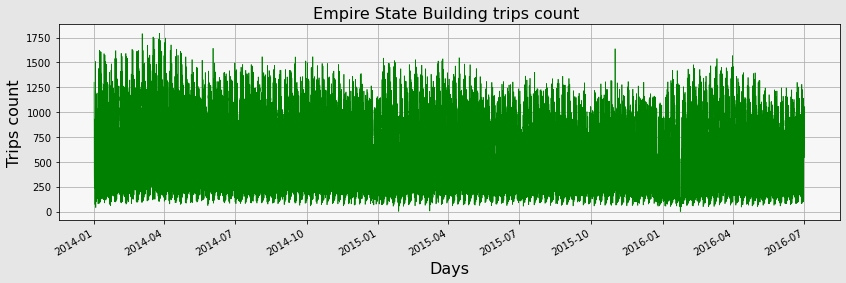

```python
fig, ax = plt.subplots(figsize=(14,4))
fig.set_facecolor('.9')
ax.set_facecolor('.97')
grouped_index_14_16.Count.plot(color='#008000', linewidth=0.7)

ax.grid(axis='both')
plt.title('Empire State Building trips count ', fontsize=16)
plt.xlabel('Days', fontsize=16)
plt.ylabel('Trips count', fontsize=16)
```

# Check and input missing values

```python
date_rng = pd.date_range(start='2014-01-01', end='2016-06-30 23:00:00', freq='H')
```

```python
date_rng
```

```
DatetimeIndex(['2014-01-01 00:00:00', '2014-01-01 01:00:00',
               '2014-01-01 02:00:00', '2014-01-01 03:00:00',
               '2014-01-01 04:00:00', '2014-01-01 05:00:00',
               '2014-01-01 06:00:00', '2014-01-01 07:00:00',
               '2014-01-01 08:00:00', '2014-01-01 09:00:00',
               ...
               '2016-06-30 14:00:00', '2016-06-30 15:00:00',
               '2016-06-30 16:00:00', '2016-06-30 17:00:00',
               '2016-06-30 18:00:00', '2016-06-30 19:00:00',
               '2016-06-30 20:00:00', '2016-06-30 21:00:00',
               '2016-06-30 22:00:00', '2016-06-30 23:00:00'],
              dtype='datetime64[ns]', length=21888, freq='H')
```

```python
grouped_index_14_16_add=pd.DataFrame({'Count': 0},index=date_rng )
```

```python
grouped_index_14_16=grouped_index_14_16.sort_index()
```

```python
grouped_index_14_16=grouped_index_14_16.append(grouped_index_14_16_add)
```

## Check missed values

```python
grouped=grouped_index_14_16.groupby(grouped_index_14_16.index)['Count'].sum().to_frame()
```

```python
criteria=grouped.Count==0
grouped[criteria]
```

|  | Count |
| --- | --- |
| 2014-03-09 02:00:00 | 0 |
| 2015-01-27 01:00:00 | 0 |
| 2015-01-27 03:00:00 | 0 |
| 2015-01-27 05:00:00 | 0 |
| 2016-01-23 17:00:00 | 0 |
| 2016-01-23 19:00:00 | 0 |
| 2016-01-23 20:00:00 | 0 |
| 2016-01-23 21:00:00 | 0 |
| 2016-01-23 22:00:00 | 0 |
| 2016-01-24 00:00:00 | 0 |
| 2016-01-24 01:00:00 | 0 |
| 2016-01-24 03:00:00 | 0 |
| 2016-01-24 04:00:00 | 0 |
| 2016-01-24 05:00:00 | 0 |
| 2016-03-13 02:00:00 | 0 |

## Change missing values to the mean of nearest neighbors

```python
grouped.loc['2014-03-09 02:00:00','Count']=int((grouped.Count.loc['2014-03-09 03:00:00']+grouped.Count.loc['2014-03-09 01:00:00'])/2)
```

```python
grouped.loc['2015-01-27 01:00:00','Count']=int((grouped.Count.loc['2015-01-27 00:00:00']+grouped.Count.loc['2015-01-27 02:00:00'])/2)
```

```python
grouped.loc['2015-01-27 03:00:00','Count']=int((grouped.Count.loc['2015-01-27 02:00:00']+grouped.Count.loc['2015-01-27 04:00:00'])/2)
```

```python
grouped.loc['2015-01-27 05:00:00','Count']=int((grouped.Count.loc['2015-01-27 04:00:00']+grouped.Count.loc['2015-01-27 06:00:00'])/2)
```

```python
grouped.loc['2016-03-13 02:00:00','Count']=int((grouped.Count.loc['2016-03-13 01:00:00']+grouped.Count.loc['2016-03-13 03:00:00'])/2)
```

## Compare average data for January by year

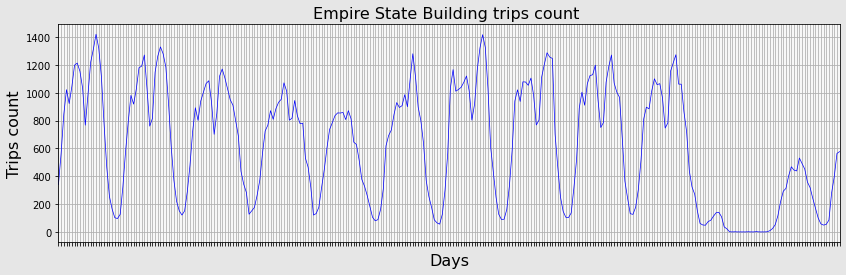

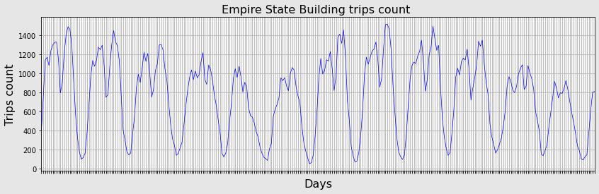

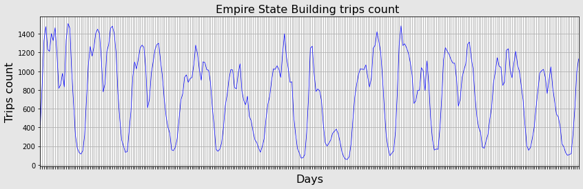

```python
fig, ax = plt.subplots(figsize=(14,4))
fig.set_facecolor('.9')
ax.set_facecolor('.97')
grouped.loc['2016-01-13 06:00:00':'2016-01-25 09:00:00'].Count.plot(color='b', linewidth=0.7)
xticks=grouped.loc['2016-01-13 06:00:00':'2016-01-25 09:00:00'].index
ax.set_xticks(xticks)
ax.grid(axis='both')
plt.title('Empire State Building trips count ', fontsize=16)
plt.xlabel('Days', fontsize=16)
plt.ylabel('Trips count', fontsize=16)

fig, ax = plt.subplots(figsize=(14,4))
fig.set_facecolor('.9')
ax.set_facecolor('.97')
grouped.loc['2015-01-14 06:00:00':'2015-01-26 09:00:00'].Count.plot(color='b', linewidth=0.7)
xticks=grouped.loc['2015-01-14 06:00:00':'2015-01-26 09:00:00'].index
ax.set_xticks(xticks)
ax.grid(axis='both')
plt.title('Empire State Building trips count ', fontsize=16)
plt.xlabel('Days', fontsize=16)
plt.ylabel('Trips count', fontsize=16)

fig, ax = plt.subplots(figsize=(14,4))
fig.set_facecolor('.9')
ax.set_facecolor('.97')
grouped.loc['2014-01-15 06:00:00':'2014-01-27 09:00:00'].Count.plot(color='b', linewidth=0.7)
xticks=grouped.loc['2014-01-15 06:00:00':'2014-01-27 09:00:00'].index
ax.set_xticks(xticks)
ax.grid(axis='both')
plt.title('Empire State Building trips count ', fontsize=16)
plt.xlabel('Days', fontsize=16)
plt.ylabel('Trips count', fontsize=16)
```

The plots show us that the data is distributed at the same diapasone by year: from 100 to 1400 trips per hour

## Determine the averaging range

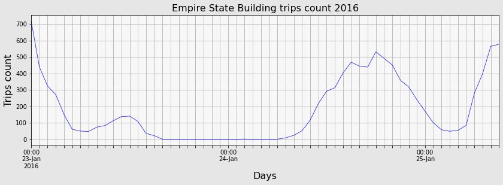

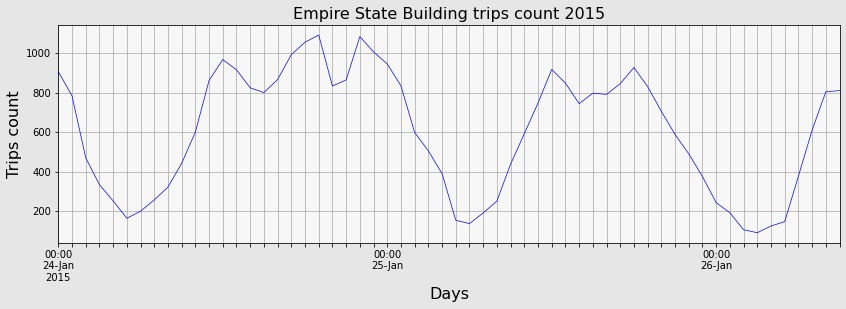

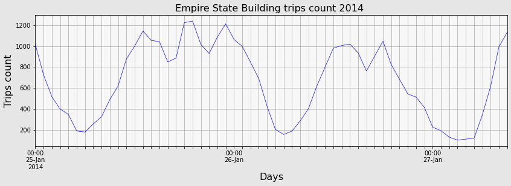

```python
fig, ax = plt.subplots(figsize=(14,4))
fig.set_facecolor('.9')
ax.set_facecolor('.97')
grouped.loc['2016-01-23 00:00:00':'2016-01-25 09:00:00'].Count.plot(color='b', linewidth=0.7)
xticks=grouped.loc['2016-01-23 00:00:00':'2016-01-25 09:00:00'].index
ax.set_xticks(xticks)
ax.grid(axis='both')
plt.title('Empire State Building trips count 2016', fontsize=16)
plt.xlabel('Days', fontsize=16)
plt.ylabel('Trips count', fontsize=16)

fig, ax = plt.subplots(figsize=(14,4))
fig.set_facecolor('.9')
ax.set_facecolor('.97')
grouped.loc['2015-01-24 00:00:00':'2015-01-26 09:00:00'].Count.plot(color='b', linewidth=0.7)
xticks=grouped.loc['2015-01-24 00:00:00':'2015-01-26 09:00:00'].index
ax.set_xticks(xticks)
ax.grid(axis='both')
plt.title('Empire State Building trips count 2015', fontsize=16)
plt.xlabel('Days', fontsize=16)
plt.ylabel('Trips count', fontsize=16)

fig, ax = plt.subplots(figsize=(14,4))
fig.set_facecolor('.9')
ax.set_facecolor('.97')
grouped.loc['2014-01-25 00:00:00':'2014-01-27 09:00:00'].Count.plot(color='b', linewidth=0.7)
xticks=grouped.loc['2014-01-25 00:00:00':'2014-01-27 09:00:00'].index
ax.set_xticks(xticks)
ax.grid(axis='both')
plt.title('Empire State Building trips count 2014 ', fontsize=16)
plt.xlabel('Days', fontsize=16)
plt.ylabel('Trips count', fontsize=16)
```

## Find the average values and replace with them data for 2016 for the observed period

```python
list_to_change=((grouped.loc['2015-01-24 05:00:00':'2015-01-26 09:00:00'].Count.values+grouped.loc['2014-01-25 05:00:00':'2014-01-27 09:00:00'].Count.values)/2).astype('int')
```

```python
grouped.loc['2016-01-23 05:00:00':'2016-01-25 09:00:00','Count']=list_to_change
```

```python
grouped.loc['2016-01-23 05:00:00':'2016-01-25 09:00:00'].Count.values
```

```
array([ 176,  189,  256,  323,  465,  609,  869,  984, 1030,  940,  921,
        857,  939, 1140, 1165,  924,  897, 1085, 1109, 1005,  916,  722,
        596,  407,  178,  146,  188,  268,  420,  604,  773,  949,  927,
        882,  866,  776,  875,  987,  826,  693,  565,  501,  394,  233,
        191,  117,   96,  117,  133,  359,  612,  899,  970], dtype=int64)
```

## Check the result

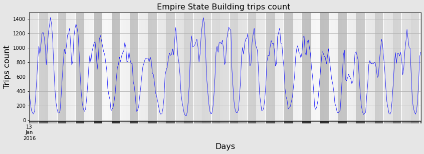

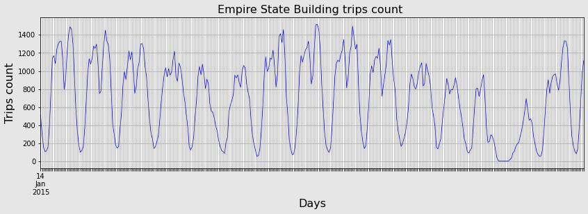

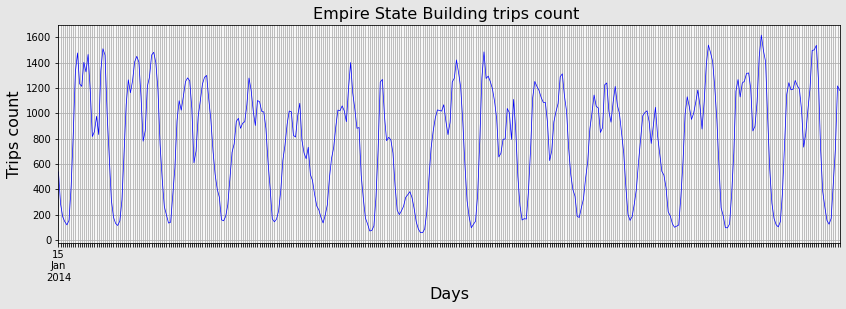

```python
fig, ax = plt.subplots(figsize=(14,4))
fig.set_facecolor('.9')
ax.set_facecolor('.97')
grouped.loc['2016-01-13 00:00:00':'2016-01-28 09:00:00'].Count.plot(color='b', linewidth=0.7)
xticks=grouped.loc['2016-01-13 00:00:00':'2016-01-28 09:00:00'].index
ax.set_xticks(xticks)
ax.grid(axis='both')
plt.title('Empire State Building trips count ', fontsize=16)
plt.xlabel('Days', fontsize=16)
plt.ylabel('Trips count', fontsize=16)

fig, ax = plt.subplots(figsize=(14,4))
fig.set_facecolor('.9')
ax.set_facecolor('.97')
grouped.loc['2015-01-14 00:00:00':'2015-01-29 09:00:00'].Count.plot(color='b', linewidth=0.7)
xticks=grouped.loc['2015-01-14 00:00:00':'2015-01-29 09:00:00'].index
ax.set_xticks(xticks)
ax.grid(axis='both')
plt.title('Empire State Building trips count ', fontsize=16)
plt.xlabel('Days', fontsize=16)
plt.ylabel('Trips count', fontsize=16)

fig, ax = plt.subplots(figsize=(14,4))
fig.set_facecolor('.9')
ax.set_facecolor('.97')
grouped.loc['2014-01-15 00:00:00':'2014-01-30 09:00:00'].Count.plot(color='b', linewidth=0.7)
xticks=grouped.loc['2014-01-15 00:00:00':'2014-01-30 09:00:00'].index
ax.set_xticks(xticks)
ax.grid(axis='both')
plt.title('Empire State Building trips count ', fontsize=16)
plt.xlabel('Days', fontsize=16)
plt.ylabel('Trips count', fontsize=16)
```

Looks good

## Check again for missing values

Everything is ok

```python
criteria=grouped.Count==0
grouped[criteria]
```

|  | Count |
| --- | --- |

# New regression features mastering

## Add holidays

### Load the holidays data table from internet

```python
base_url ='https://www.officeholidays.com/countries/usa/2020'
df_list = pd.read_html(base_url, flavor='html5lib')
usa_holidays=df_list[0]
```

```python
# delete the row as it is the holiday in another state
usa_holidays=usa_holidays.drop([11])
usa_holidays
```

|  | Day | Date | Holiday Name | Type | Comments |
| --- | --- | --- | --- | --- | --- |
| 0 | Wednesday | Jan 01 | New Year's Day | Federal Holiday | NaN |
| 1 | Monday | Jan 20 | Martin Luther King Jr. Day | Federal Holiday | 3rd Monday in January |
| 2 | Monday | Feb 17 | President's Day | Federal Holiday | 3rd Monday in February |
| 3 | Sunday | May 10 | Mother's Day | Not A Public Holiday | 2nd Sunday in May. Not a public holiday |
| 4 | Monday | May 25 | Memorial Day | Federal Holiday | Last Monday in May |
| 5 | Sunday | Jun 21 | Father's Day | Not A Public Holiday | 3rd Sunday in June. Not a public holiday |
| 6 | Friday | Jul 03 | Independence Day (in lieu) | Regional Holiday | NaN |
| 7 | Friday | Jul 03 | Independence Day (in lieu) | Federal Holiday | NaN |
| 8 | Saturday | Jul 04 | Independence Day | Federal Holiday | NaN |
| 9 | Monday | Jul 06 | Independence Day (in lieu) | Regional Holiday | NaN |
| 10 | Monday | Sep 07 | Labor Day | Federal Holiday | 1st Monday in September |
| 12 | Monday | Oct 12 | Columbus Day | Federal Holiday | 2nd Monday in October |
| 13 | Monday | Oct 12 | US Indigenous People's Day | Regional Holiday | NaN |
| 14 | Wednesday | Nov 11 | Veterans Day | Federal Holiday | NaN |
| 15 | Thursday | Nov 26 | Thanksgiving | Federal Holiday | 4th Thursday in November |
| 16 | Friday | Nov 27 | Day after Thanksgiving | Regional Holiday | Day after 4th Thursday in November |
| 17 | Thursday | Dec 24 | Christmas Eve | Regional Holiday | NaN |
| 18 | Friday | Dec 25 | Christmas Day | Federal Holiday | NaN |
| 19 | Thursday | Dec 31 | New Year's Eve | Regional Holiday | NaN |

```python
usa_holidays.info()
```

```
<class 'pandas.core.frame.DataFrame'>
Int64Index: 19 entries, 0 to 19
Data columns (total 5 columns):
 #   Column        Non-Null Count  Dtype
---  ------        --------------  -----
 0   Day           19 non-null     object
 1   Date          19 non-null     object
 2   Holiday Name  19 non-null     object
 3   Type          19 non-null     object
 4   Comments      9 non-null      object
dtypes: object(5)
memory usage: 912.0+ bytes
```

### Add new columns for rolling holidays date transformation

```python
usa_holidays['2020']='2020 '+usa_holidays['Date']
usa_holidays['2020']=pd.to_datetime(usa_holidays['2020'])
usa_holidays['day_of_week']=0
usa_holidays['number_of_week']=0
```

```python
usa_holidays.head(3)
```

|  | Day | Date | Holiday Name | Type | Comments | 2020 | day_of_week | number_of_week |
| --- | --- | --- | --- | --- | --- | --- | --- | --- |
| 0 | Wednesday | Jan 01 | New Year's Day | Federal Holiday | NaN | 2020-01-01 | 0 | 0 |
| 1 | Monday | Jan 20 | Martin Luther King Jr. Day | Federal Holiday | 3rd Monday in January | 2020-01-20 | 0 | 0 |
| 2 | Monday | Feb 17 | President's Day | Federal Holiday | 3rd Monday in February | 2020-02-17 | 0 | 0 |

### Leave only rows with dates depending on the days of the week

```python
criteria_1=usa_holidays.Comments.notna()
usa_holidays_1=usa_holidays[criteria_1]
```

```python
list_of_days=[5,0,0,6,0,6,5,5,5,5,0,0,5,5,3,4,5,5,5]
list_of_weeks_numbers=[0,2,2,1,3,2,0,0,0,0,0,1,0,0,3,3,0,0,0]

usa_holidays.loc[:, 'day_of_week']=list_of_days
usa_holidays.loc[:, 'number_of_week']=list_of_weeks_numbers
```

```python
usa_holidays[criteria_1]
```

|  | Day | Date | Holiday Name | Type | Comments | 2020 | day_of_week | number_of_week |
| --- | --- | --- | --- | --- | --- | --- | --- | --- |
| 1 | Monday | Jan 20 | Martin Luther King Jr. Day | Federal Holiday | 3rd Monday in January | 2020-01-20 | 0 | 2 |
| 2 | Monday | Feb 17 | President's Day | Federal Holiday | 3rd Monday in February | 2020-02-17 | 0 | 2 |
| 3 | Sunday | May 10 | Mother's Day | Not A Public Holiday | 2nd Sunday in May. Not a public holiday | 2020-05-10 | 6 | 1 |
| 4 | Monday | May 25 | Memorial Day | Federal Holiday | Last Monday in May | 2020-05-25 | 0 | 3 |
| 5 | Sunday | Jun 21 | Father's Day | Not A Public Holiday | 3rd Sunday in June. Not a public holiday | 2020-06-21 | 6 | 2 |
| 10 | Monday | Sep 07 | Labor Day | Federal Holiday | 1st Monday in September | 2020-09-07 | 0 | 0 |
| 12 | Monday | Oct 12 | Columbus Day | Federal Holiday | 2nd Monday in October | 2020-10-12 | 0 | 1 |
| 15 | Thursday | Nov 26 | Thanksgiving | Federal Holiday | 4th Thursday in November | 2020-11-26 | 3 | 3 |
| 16 | Friday | Nov 27 | Day after Thanksgiving | Regional Holiday | Day after 4th Thursday in November | 2020-11-27 | 4 | 3 |

```python
def date_calculate(year):
    date_list=[]
    for y,i,j in zip(usa_holidays['2020'].dt.month.tolist(),usa_holidays['number_of_week'].tolist(), usa_holidays['day_of_week'].tolist()  ):

        if calendar.monthcalendar(year,y)[0][j] ==0:
            res=datetime(year,y,calendar.monthcalendar(year,y)[i+1][j])
        else:
            res=datetime(year,y,calendar.monthcalendar(year,y)[i][j])
        date_list.append(res)
    return date_list
```

```python
usa_holidays['2014']=date_calculate(2014)
usa_holidays['2015']=date_calculate(2015)
usa_holidays['2016']=date_calculate(2016)
```

### Add the columns with other holidays

```python
usa_holidays['2016_2']='2016 '+usa_holidays['Date']
usa_holidays['2016_2']=pd.to_datetime(usa_holidays['2016_2'])


usa_holidays['2015_2']='2015 '+usa_holidays['Date']
usa_holidays['2015_2']=pd.to_datetime(usa_holidays['2015_2'])


usa_holidays['2014_2']='2014 '+usa_holidays['Date']
usa_holidays['2014_2']=pd.to_datetime(usa_holidays['2014_2'])
```

### Join dates

```python
usa_holidays['2014'] = np.where(~criteria_1, usa_holidays['2014_2'], usa_holidays['2014'])
usa_holidays['2015'] = np.where(~criteria_1, usa_holidays['2015_2'], usa_holidays['2015'])
usa_holidays['2016'] = np.where(~criteria_1, usa_holidays['2016_2'], usa_holidays['2016'])
```

```python
usa_holidays[criteria_1].head(2)
```

|  | Day | Date | Holiday Name | Type | Comments | 2020 | day_of_week | number_of_week | 2014 | 2015 | 2016 | 2016_2 | 2015_2 | 2014_2 |
| --- | --- | --- | --- | --- | --- | --- | --- | --- | --- | --- | --- | --- | --- | --- |
| 1 | Monday | Jan 20 | Martin Luther King Jr. Day | Federal Holiday | 3rd Monday in January | 2020-01-20 | 0 | 2 | 2014-01-20 | 2015-01-19 | 2016-01-18 | 2016-01-20 | 2015-01-20 | 2014-01-20 |
| 2 | Monday | Feb 17 | President's Day | Federal Holiday | 3rd Monday in February | 2020-02-17 | 0 | 2 | 2014-02-17 | 2015-02-16 | 2016-02-15 | 2016-02-17 | 2015-02-17 | 2014-02-17 |

### Delete temporarily used columns

```python
usa_holidays=usa_holidays.iloc[:,[8,9,10]]
```

```python
usa_holidays.head(2)
```

|  | 2014 | 2015 | 2016 |
| --- | --- | --- | --- |
| 0 | 2014-01-01 | 2015-01-01 | 2016-01-01 |
| 1 | 2014-01-20 | 2015-01-19 | 2016-01-18 |

### Add columns with pre- and day after the holiday

```python
delta=timedelta(days=1)
```

```python
usa_holidays=usa_holidays['2014'].append(usa_holidays['2015']).append(usa_holidays['2016'])
```

```python
usa_holidays=usa_holidays.to_frame(name='holidays')
usa_holidays['day_before']=usa_holidays['holidays']-delta
```

```python
usa_holidays['day_after']=usa_holidays['holidays']+delta
```

```python
usa_holidays.head(2)
```

|  | holidays | day_before | day_after |
| --- | --- | --- | --- |
| 0 | 2014-01-01 | 2013-12-31 | 2014-01-02 |
| 1 | 2014-01-20 | 2014-01-19 | 2014-01-21 |

```python
hol_list_hol=usa_holidays.holidays.tolist()
hol_list_before=usa_holidays.day_before.tolist()
hol_list_after=usa_holidays.day_after.tolist()
```

```python
criteria_hol=pd.to_datetime(grouped.index.strftime('%Y-%m-%d')).isin(hol_list_hol)
criteria_before=pd.to_datetime(grouped.index.strftime('%Y-%m-%d')).isin(hol_list_before)
criteria_after=pd.to_datetime(grouped.index.strftime('%Y-%m-%d')).isin(hol_list_after)
```

```python
grouped['hol']=np.where(criteria_hol, 1, 0)
grouped['before_hol']=np.where(criteria_before, 1, 0)
grouped['after_hol']=np.where(criteria_after, 1, 0)
```

## Add intercept

```python
grouped['w_0']=1
```

## Add trend

```python
T=len(grouped)
t=np.linspace(1,T, T)
#grouped['w_t']=t
```

## Week's periodic features

Общая формула:

$$ s_i = \sin \left( [1,\dots,T] * 2 \pi i/ 168 \right),\space c_i = \cos \left( [1,\dots,T] * 2 \pi i/ 168 \right), i=1,\dots, K $$

```python
for j in range(50):
    i=j+1
    name='sw_'+str(i)
    new_column_values=np.sin(t*2*np.pi*i/168)
    grouped[name]=new_column_values

for j in range(50):
    i=j+1
    name='cw_'+str(i)
    new_column_values=np.cos(t*2*np.pi*i/168)
    grouped[name]=new_column_values
```

```python
grouped.head(2)
```

|  | Count | hol | before_hol | after_hol | w_0 | sw_1 | sw_2 | sw_3 | sw_4 | sw_5 | ... | cw_41 | cw_42 | cw_43 | cw_44 | cw_45 | cw_46 | cw_47 | cw_48 | cw_49 | cw_50 |
| --- | --- | --- | --- | --- | --- | --- | --- | --- | --- | --- | --- | --- | --- | --- | --- | --- | --- | --- | --- | --- | --- |
| 2014-01-01 00:00:00 | 1300 | 1 | 0 | 0 | 1 | 0.037391 | 0.074730 | 0.111964 | 0.149042 | 0.185912 | ... | 0.037391 | 6.123234e-17 | -0.037391 | -0.074730 | -0.111964 | -0.149042 | -0.185912 | -0.222521 | -0.258819 | -0.294755 |
| 2014-01-01 01:00:00 | 788 | 1 | 0 | 0 | 1 | 0.074730 | 0.149042 | 0.222521 | 0.294755 | 0.365341 | ... | -0.997204 | -1.000000e+00 | -0.997204 | -0.988831 | -0.974928 | -0.955573 | -0.930874 | -0.900969 | -0.866025 | -0.826239 |

2 rows × 105 columns

## Year's periodic features

Общая формула:

$$ s_i = \sin \left( [1,\dots,T] * 2 \pi i/ 8766 \right),\space c_i = \cos \left( [1,\dots,T] * 2 \pi i/ 8766 \right), i=1,\dots, K $$

```python
for j in range(50):
    i=j+1
    name='sy_'+str(i)
    new_column_values=np.sin(t*2*np.pi*i/8766)
    grouped[name]=new_column_values

for j in range(50):
    i=j+1
    name='cy_'+str(i)
    new_column_values=np.cos(t*2*np.pi*i/8766)
    grouped[name]=new_column_values
```

```python
grouped.head(2)
```

|  | Count | hol | before_hol | after_hol | w_0 | sw_1 | sw_2 | sw_3 | sw_4 | sw_5 | ... | cy_41 | cy_42 | cy_43 | cy_44 | cy_45 | cy_46 | cy_47 | cy_48 | cy_49 | cy_50 |
| --- | --- | --- | --- | --- | --- | --- | --- | --- | --- | --- | --- | --- | --- | --- | --- | --- | --- | --- | --- | --- | --- |
| 2014-01-01 00:00:00 | 1300 | 1 | 0 | 0 | 1 | 0.037391 | 0.074730 | 0.111964 | 0.149042 | 0.185912 | ... | 0.999568 | 0.999547 | 0.999525 | 0.999503 | 0.99948 | 0.999456 | 0.999433 | 0.999408 | 0.999383 | 0.999358 |
| 2014-01-01 01:00:00 | 788 | 1 | 0 | 0 | 1 | 0.074730 | 0.149042 | 0.222521 | 0.294755 | 0.365341 | ... | 0.998273 | 0.998188 | 0.998101 | 0.998011 | 0.99792 | 0.997827 | 0.997731 | 0.997634 | 0.997534 | 0.997432 |

2 rows × 205 columns

## Day's periodic features

```python
for j in range(50):
    i=j+1
    name='sh_'+str(i)
    new_column_values=np.sin(t*2*np.pi*i/24)
    grouped[name]=new_column_values

for j in range(50):
    i=j+1
    name='ch_'+str(i)
    new_column_values=np.cos(t*2*np.pi*i/24)
    grouped[name]=new_column_values
```

```python
grouped.head(2)
```

|  | Count | hol | before_hol | after_hol | w_0 | sw_1 | sw_2 | sw_3 | sw_4 | sw_5 | ... | ch_41 | ch_42 | ch_43 | ch_44 | ch_45 | ch_46 | ch_47 | ch_48 | ch_49 | ch_50 |
| --- | --- | --- | --- | --- | --- | --- | --- | --- | --- | --- | --- | --- | --- | --- | --- | --- | --- | --- | --- | --- | --- |
| 2014-01-01 00:00:00 | 1300 | 1 | 0 | 0 | 1 | 0.037391 | 0.074730 | 0.111964 | 0.149042 | 0.185912 | ... | -0.258819 | -4.286264e-16 | 0.258819 | 0.5 | 7.071068e-01 | 0.866025 | 0.965926 | 1.0 | 0.965926 | 0.866025 |
| 2014-01-01 01:00:00 | 788 | 1 | 0 | 0 | 1 | 0.074730 | 0.149042 | 0.222521 | 0.294755 | 0.365341 | ... | -0.866025 | -1.000000e+00 | -0.866025 | -0.5 | 8.578717e-16 | 0.500000 | 0.866025 | 1.0 | 0.866025 | 0.500000 |

2 rows × 305 columns

# Split to train and test samples

```python
test_gr=grouped.loc['2016-05-01':'2016-05-30']
```

```python
train=grouped.loc[:'2016-04-30 23:00:00']
```

```python
test_gr.head(2)
```

|  | Count | hol | before_hol | after_hol | w_0 | sw_1 | sw_2 | sw_3 | sw_4 | sw_5 | ... | ch_41 | ch_42 | ch_43 | ch_44 | ch_45 | ch_46 | ch_47 | ch_48 | ch_49 | ch_50 |
| --- | --- | --- | --- | --- | --- | --- | --- | --- | --- | --- | --- | --- | --- | --- | --- | --- | --- | --- | --- | --- | --- |
| 2016-05-01 00:00:00 | 881 | 0 | 0 | 0 | 1 | -0.467269 | 0.826239 | -0.993712 | 0.930874 | -0.652287 | ... | -0.258819 | 1.040687e-11 | 0.258819 | 0.5 | 7.071068e-01 | 0.866025 | 0.965926 | 1.0 | 0.965926 | 0.866025 |
| 2016-05-01 01:00:00 | 713 | 0 | 0 | 0 | 1 | -0.500000 | 0.866025 | -1.000000 | 0.866025 | -0.500000 | ... | -0.866025 | -1.000000e+00 | -0.866025 | -0.5 | 6.477049e-12 | 0.500000 | 0.866025 | 1.0 | 0.866025 | 0.500000 |

2 rows × 305 columns

```python
train.head(2)
```

|  | Count | hol | before_hol | after_hol | w_0 | sw_1 | sw_2 | sw_3 | sw_4 | sw_5 | ... | ch_41 | ch_42 | ch_43 | ch_44 | ch_45 | ch_46 | ch_47 | ch_48 | ch_49 | ch_50 |
| --- | --- | --- | --- | --- | --- | --- | --- | --- | --- | --- | --- | --- | --- | --- | --- | --- | --- | --- | --- | --- | --- |
| 2014-01-01 00:00:00 | 1300 | 1 | 0 | 0 | 1 | 0.037391 | 0.074730 | 0.111964 | 0.149042 | 0.185912 | ... | -0.258819 | -4.286264e-16 | 0.258819 | 0.5 | 7.071068e-01 | 0.866025 | 0.965926 | 1.0 | 0.965926 | 0.866025 |
| 2014-01-01 01:00:00 | 788 | 1 | 0 | 0 | 1 | 0.074730 | 0.149042 | 0.222521 | 0.294755 | 0.365341 | ... | -0.866025 | -1.000000e+00 | -0.866025 | -0.5 | 8.578717e-16 | 0.500000 | 0.866025 | 1.0 | 0.866025 | 0.500000 |

2 rows × 305 columns

# Model selection

## Feature selection

### Select 40 the most important features

```python
import pandas as pd
import numpy as np
from sklearn.feature_selection import SelectKBest
from sklearn.feature_selection import f_regression

x=train.iloc[:,1:]
y=np.array(train.iloc[:,:1:]).reshape(-1)
#apply SelectKBest class to extract top 40 best features
bestfeatures = SelectKBest(score_func=f_regression, k=40)
fit = bestfeatures.fit(x,y)
dfscores = pd.DataFrame(fit.scores_)
dfcolumns = pd.DataFrame(x.columns)
#concat two dataframes for better visualization
featureScores = pd.concat([dfcolumns,dfscores],axis=1)
featureScores.columns = ['Specs','Score']  #naming the dataframe columns
print(featureScores.nlargest(40,'Score'))  #print 40 best features
```

```
     Specs         Score
250  sh_47  16593.524131
226  sh_23  16593.524131
204   sh_1  16593.524131
10    sw_7  16593.524131
228  sh_25  16593.524131
252  sh_49  16593.524131
299  ch_46   3538.049824
275  ch_22   3538.049824
67   cw_14   3538.049824
255   ch_2   3538.049824
279  ch_26   3538.049824
303  ch_50   3538.049824
253  sh_50   1367.712178
229  sh_26   1367.712178
```

[output cut: 26 more lines]

```python
column_list=featureScores.nlargest(40,'Score').Specs.tolist()
column_list2=['Count','hol','before_hol','after_hol']
column_list=column_list2+column_list
```

```python
train_regected=train[sorted(column_list)]
```

```python
train_regected.head(2)
```

|  | Count | after_hol | before_hol | ch_1 | ch_19 | ch_2 | ch_20 | ch_22 | ch_23 | ch_25 | ... | sh_25 | sh_26 | sh_46 | sh_47 | sh_49 | sh_50 | sw_1 | sw_13 | sw_14 | sw_7 |
| --- | --- | --- | --- | --- | --- | --- | --- | --- | --- | --- | --- | --- | --- | --- | --- | --- | --- | --- | --- | --- | --- |
| 2014-01-01 00:00:00 | 1300 | 0 | 0 | 0.965926 | 0.258819 | 0.866025 | 0.5 | 0.866025 | 0.965926 | 0.965926 | ... | 0.258819 | 0.500000 | -0.500000 | -0.258819 | 0.258819 | 0.500000 | 0.037391 | 0.467269 | 0.500000 | 0.258819 |
| 2014-01-01 01:00:00 | 788 | 0 | 0 | 0.866025 | -0.866025 | 0.500000 | -0.5 | 0.500000 | 0.866025 | 0.866025 | ... | 0.500000 | 0.866025 | -0.866025 | -0.500000 | 0.500000 | 0.866025 | 0.074730 | 0.826239 | 0.866025 | 0.500000 |

2 rows × 44 columns

## Model selection

```python
# Compare Algorithms
import pandas
import matplotlib.pyplot as plt
from sklearn import model_selection
from sklearn.linear_model import LinearRegression
from sklearn.tree import DecisionTreeRegressor
from sklearn.ensemble import RandomForestRegressor
from xgboost import XGBRegressor
```

```python
train=train_regected
X=np.array(train.iloc[:,1:])
Y=np.array(train.iloc[:,:1:]).reshape(-1)
```

```
LR: 0.814141 (0.008154)
DT: 0.879473 (0.008288)
RFR: 0.881835 (0.007981)
XGBR: 0.887361 (0.007582)
```

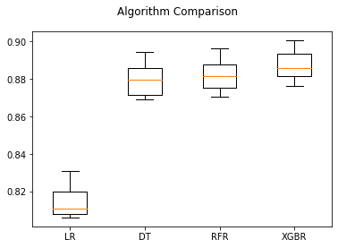

```python
# prepare configuration for cross validation test harness
seed = 7
# prepare models
models = []
models.append(('LR', LinearRegression()))
models.append(('DT', DecisionTreeRegressor()))
models.append(('RFR', RandomForestRegressor()))
models.append(('XGBR', XGBRegressor()))

# evaluate each model in turn
results = []
names = []
scoring = 'r2'
for name, model in models:
    kfold = model_selection.KFold(n_splits=10, random_state=seed,shuffle=True)
    cv_results = model_selection.cross_val_score(model, X, Y, cv=kfold, scoring=scoring)
    results.append(cv_results)
    names.append(name)
    msg = "%s: %f (%f)" % (name, cv_results.mean(), cv_results.std())
    print(msg)
# boxplot algorithm comparison
fig = plt.figure()
fig.suptitle('Algorithm Comparison')
ax = fig.add_subplot(111)
plt.boxplot(results)
ax.set_xticklabels(names)
plt.show()
```

## XGBRegressor

```python
train=train_regected

X=np.array(train.iloc[:,1:])
Y=np.array(train.iloc[:,:1:]).reshape(-1)

model = XGBRegressor()
# fit the model
model.fit(X, Y)
preds = model.predict(X)
model.fit(X, Y).score(X, Y)
```

```
0.9218984408076611
```

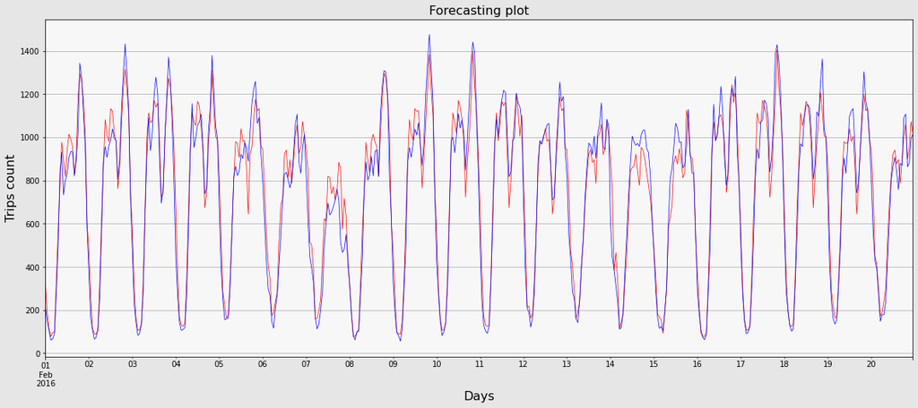

```python
train=train.assign(predict=preds)
train=train.assign(residuals=train.Count-train.predict)
fig, ax = plt.subplots(figsize=(20,8))
fig.set_facecolor('.9')
ax.set_facecolor('.97')
train.loc['2016-02-01' :'2016-02-20']['predict'].plot(color='red', linewidth=0.7, ax=ax)
train.loc['2016-02-01' :'2016-02-20']['Count'].plot(color='blue', linewidth=0.7, ax=ax)
ax.grid(axis='both')
plt.title('Forecasting plot', fontsize=16)
plt.xlabel('Days', fontsize=16)
plt.ylabel('Trips count', fontsize=16)
```

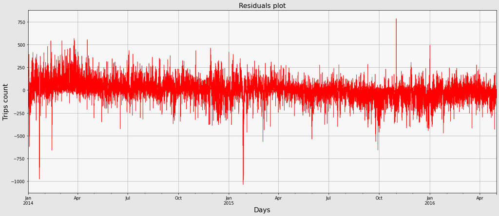

```python
fig, ax = plt.subplots(figsize=(20,8))
fig.set_facecolor('.9')
ax.set_facecolor('.97')
train['residuals'].plot(color='red', linewidth=0.7, ax=ax)

ax.grid(axis='both')
plt.title('Residuals plot', fontsize=16)
plt.xlabel('Days', fontsize=16)
plt.ylabel('Trips count', fontsize=16)
```

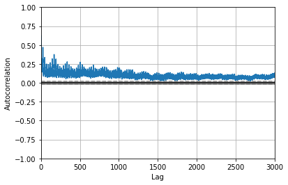

```python
# create an autocorrelation plot
from pandas.plotting import autocorrelation_plot
series = train.residuals

autocorrelation_plot(series)
plt.axis([0,3000,-1,1])
pyplot.show()
```

### XGBRegressor without differentiation

```
adf:  -5.432574273838756
p-value:  2.8925044942348033e-06
Critical values:  {'1%': -3.4326257810090195, '5%': -2.862545485752566, '10%': -2.567305249201584}
единичных корней нет, ряд стационарен
```

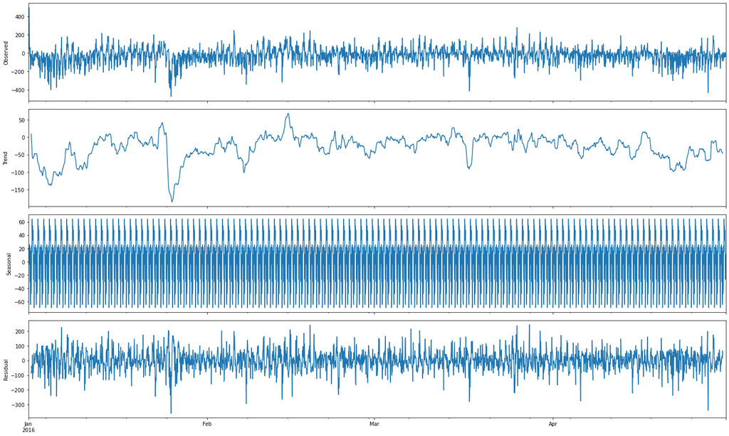

```python
plt.figure(figsize(20,12))
sm.tsa.seasonal_decompose(train.residuals.loc['2016-01-01':]).plot()
test=sm.tsa.stattools.adfuller(train.residuals.loc['2016-01-01':])
print ('adf: ', test[0])
print ('p-value: ', test[1])
print ('Critical values: ', test[4])
if test[0]> test[4]['5%']:
    print ('есть единичные корни, ряд не стационарен')
else:
    print ('единичных корней нет, ряд стационарен')
```

```
Критерий Дики-Фуллера: p=0.027323
```

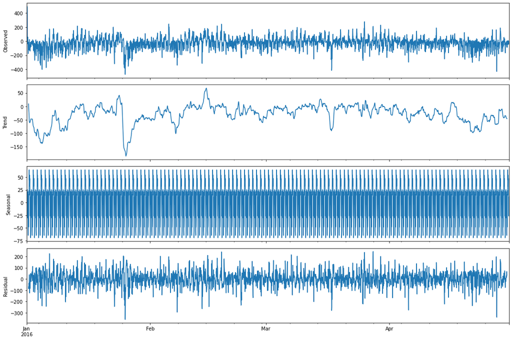

```python
plt.figure(figsize(15,10))
sm.tsa.seasonal_decompose(train.residuals.loc['2016-01-01':]).plot()
print("Критерий Дики-Фуллера: p=%f" % sm.tsa.stattools.adfuller(train.residuals.loc['2016-01-01':'2016-02-01'])[1])
```

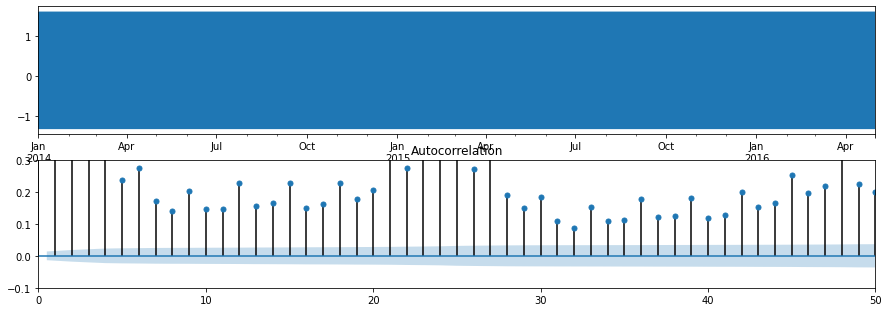

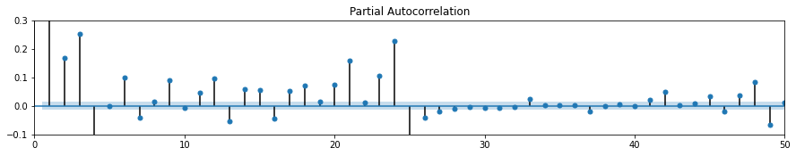

```python
res=sm.tsa.seasonal_decompose(train['residuals'])
plt.figure(figsize(15,8))
ax = plt.subplot(311)
res.seasonal.plot()
ax = plt.subplot(312)
sm.graphics.tsa.plot_acf(train['residuals'].values.squeeze(), lags=50, ax=ax)
plt.axis([0,50,-0.1,0.3])
pylab.show()
ax = plt.subplot(313)
sm.graphics.tsa.plot_pacf(train['residuals'].values.squeeze(), lags=50, ax=ax)
plt.axis([0,50,-0.1,0.3])
pylab.show()
```

### XGBRegressor with differentiation

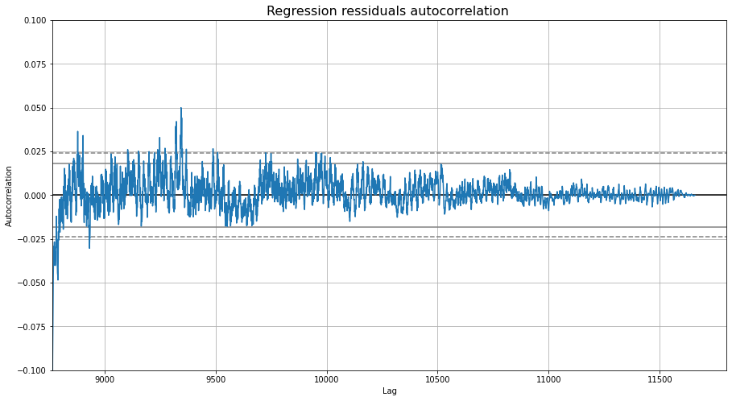

```python
n=1
N=0
nseason=n*8766
train=train.assign(residual_diff=train.residuals - train.residuals.shift(nseason))
train=train.assign(residual_diff2=train.residual_diff - train.residual_diff.shift(N))
autocorrelation_plot(train.residual_diff[nseason:])
plt.axis([8766,11800,-0.1,0.1])
plt.title('Regression ressiduals autocorrelation ', fontsize=16)
pyplot.show()
```

```python
train.head(2)
```

|  | Count | after_hol | before_hol | ch_1 | ch_19 | ch_2 | ch_20 | ch_22 | ch_23 | ch_25 | ... | sh_49 | sh_50 | sw_1 | sw_13 | sw_14 | sw_7 | predict | residuals | residual_diff | residual_diff2 |
| --- | --- | --- | --- | --- | --- | --- | --- | --- | --- | --- | --- | --- | --- | --- | --- | --- | --- | --- | --- | --- | --- |
| 2014-01-01 00:00:00 | 1300 | 0 | 0 | 0.965926 | 0.258819 | 0.866025 | 0.5 | 0.866025 | 0.965926 | 0.965926 | ... | 0.258819 | 0.500000 | 0.037391 | 0.467269 | 0.500000 | 0.258819 | 786.656982 | 513.343018 | NaN | NaN |
| 2014-01-01 01:00:00 | 788 | 0 | 0 | 0.866025 | -0.866025 | 0.500000 | -0.5 | 0.500000 | 0.866025 | 0.866025 | ... | 0.500000 | 0.866025 | 0.074730 | 0.826239 | 0.866025 | 0.500000 | 608.245056 | 179.754944 | NaN | NaN |

2 rows × 48 columns

```
Критерий Дики-Фуллера: p=0.000000
```

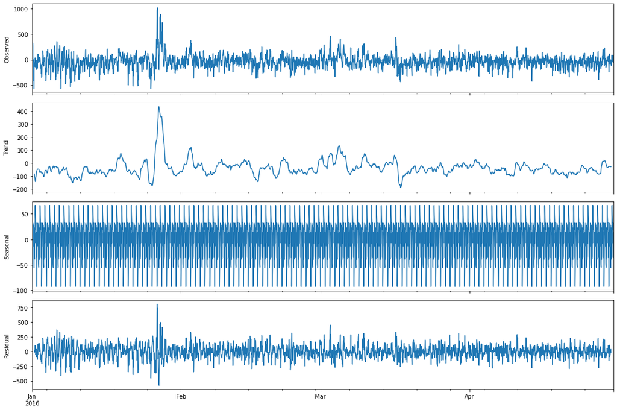

```python
plt.figure(figsize(15,10))
sm.tsa.seasonal_decompose(train.residual_diff['2016-01-01':]).plot()
print("Критерий Дики-Фуллера: p=%f" % sm.tsa.stattools.adfuller(train.residual_diff['2016-01-01':])[1])
```

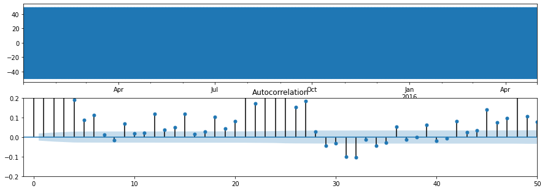

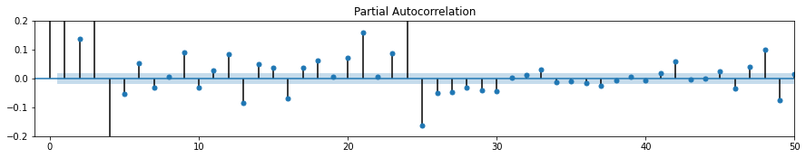

```python
res=sm.tsa.seasonal_decompose(train.residual_diff[8766:])
plt.figure(figsize(15,8))
ax = plt.subplot(311)
res.seasonal.plot()
ax = plt.subplot(312)
sm.graphics.tsa.plot_acf(train.residual_diff[8766:].values.squeeze(), lags=50, ax=ax)
plt.axis([-1,50,-0.2,0.2])
pylab.show()
ax = plt.subplot(313)
sm.graphics.tsa.plot_pacf(train.residual_diff[8766:].values.squeeze(), lags=50, ax=ax)
plt.axis([-1,50,-0.2,0.2])
pylab.show()
```

```python
train_data=train.Count[8766:]
exog_data=train[train.columns[1:-4]][8766:]
```

# SARIMA parametrs selection

Here I left only one model, which proved to be the best in the selection process so the training will not take a long time.

```python
# параметры перебора
p=4
d=0
q=4

P=4
D=1
Q=4
s=12

ps = range(0, p+1)
d=d
qs = range(0, q+1)
Ps = range(0,P+1)
D=D
Qs = range(0, Q+1)


#parameters = product(ps, qs, Ps, Qs)
parameters_list = list([[2, 0, 4, 0]])
len(parameters_list)
```

```
1
```

```python
#%%time
results = []
best_aic = float("inf")
warnings.filterwarnings('ignore')
train_data=train_data
exog_data=exog_data
for param in parameters_list:

    try:
        model=sm.tsa.statespace.SARIMAX(train_data, exog=exog_data, order=(param[0], d, param[1]),
                                        seasonal_order=(param[2], D, param[3], 12), enforce_stationarity=False, enforce_invertibility=False).fit(disp=-1)

    except ValueError:
        print('wrong parameters:', param)
        continue

    except LinAlgError:
        print('singularity parameters:', param)
        continue



    aic = model.aic
    n+=1
    print(n, param, aic, datetime.now().strftime("%H:%M:%S"))
    # save the best model
    if aic < best_aic:
        best_model = model
        best_aic = aic
        best_param = param

    results.append([param, model.aic])

warnings.filterwarnings('default')
```

```
2 [2, 0, 4, 0] 137118.65555012622 23:59:49
```

```python
result_table = pd.DataFrame(results)
result_table.columns = ['parameters', 'aic']
print(result_table.sort_values(by = 'aic', ascending=True).head())
```

```python
print(best_model.summary())
```

```
                                 Statespace Model Results
==========================================================================================
Dep. Variable:                              Count   No. Observations:                11658
Model:             SARIMAX(2, 0, 0)x(4, 1, 0, 12)   Log Likelihood              -68509.328
Date:                            Sat, 09 May 2020   AIC                         137118.656
Time:                                    07:49:17   BIC                         137486.576
Sample:                                01-01-2015   HQIC                        137242.283
                                     - 04-30-2016
Covariance Type:                              opg
==============================================================================
                 coef    std err          z      P>|z|      [0.025      0.975]
------------------------------------------------------------------------------
after_hol     50.3011     11.815      4.257      0.000      27.145      73.458
before_hol   -48.7457      9.738     -5.006      0.000     -67.831     -29.660
ch_1        8.705e+11      0.844   1.03e+12      0.000    8.71e+11    8.71e+11
ch_19      -1.317e+11      0.318  -4.14e+11      0.000   -1.32e+11   -1.32e+11
ch_2        3.458e+12        nan        nan        nan         nan         nan
ch_20      -8.166e+11   2.88e-09  -2.83e+20      0.000   -8.17e+11   -8.17e+11
ch_22      -3.135e+11   3.84e-09  -8.17e+19      0.000   -3.14e+11   -3.14e+11
ch_23       5.801e+10      0.844   6.87e+10      0.000     5.8e+10     5.8e+10
ch_25      -1.079e+11      0.844  -1.28e+11      0.000   -1.08e+11   -1.08e+11
ch_26       9.119e+10   1.48e-09   6.17e+19      0.000    9.12e+10    9.12e+10
ch_28       4.653e+10   8.25e-10   5.64e+19      0.000    4.65e+10    4.65e+10
ch_29       2.303e+11      0.318   7.23e+11      0.000     2.3e+11     2.3e+11
ch_4       -1.277e+12   8.75e-10  -1.46e+21      0.000   -1.28e+12   -1.28e+12
ch_43      -2.258e+11      0.318  -7.09e+11      0.000   -2.26e+11   -2.26e+11
ch_44       4.222e+11   1.83e-08    2.3e+19      0.000    4.22e+11    4.22e+11
ch_46       8.159e+10    4.1e-09   1.99e+19      0.000    8.16e+10    8.16e+10
ch_47       1.217e+11      0.844   1.44e+11      0.000    1.22e+11    1.22e+11
ch_49       4.696e+10      0.844   5.56e+10      0.000     4.7e+10     4.7e+10
ch_5        1.428e+11      0.318   4.48e+11      0.000    1.43e+11    1.43e+11
ch_50      -1.833e+11   8.28e-09  -2.21e+19      0.000   -1.83e+11   -1.83e+11
cw_1          37.6023      5.244      7.170      0.000      27.324      47.881
cw_14      -1.706e+12   3.32e-10  -5.13e+21      0.000   -1.71e+12   -1.71e+12
cw_28       1.384e+12   3.06e-10   4.53e+21      0.000    1.38e+12    1.38e+12
cw_35       -1.56e+10      0.318   -4.9e+10      0.000   -1.56e+10   -1.56e+10
cw_5          44.0415      3.238     13.602      0.000      37.695      50.388
cw_6         -57.1627      4.659    -12.270      0.000     -66.294     -48.032
cw_7       -9.894e+11      0.844  -1.17e+12      0.000   -9.89e+11   -9.89e+11
cw_8         -71.8799      4.181    -17.193      0.000     -80.074     -63.686
```

[output cut: 17 more lines]

```
ar.S.L12      -0.7651      0.008    -94.799      0.000      -0.781      -0.749
ar.S.L24      -0.3094      0.010    -30.781      0.000      -0.329      -0.290
ar.S.L36      -0.2948      0.010    -29.068      0.000      -0.315      -0.275
ar.S.L48      -0.1138      0.009    -13.107      0.000      -0.131      -0.097
sigma2      8175.7995     73.913    110.614      0.000    8030.932    8320.667
===================================================================================
Ljung-Box (Q):                      670.32   Jarque-Bera (JB):              6499.12
Prob(Q):                              0.00   Prob(JB):                         0.00
Heteroskedasticity (H):               0.85   Skew:                             0.18
Prob(H) (two-sided):                  0.00   Kurtosis:                         6.65
===================================================================================

Warnings:
[1] Covariance matrix calculated using the outer product of gradients (complex-step).
[2] Covariance matrix is singular or near-singular, with condition number 1.84e+38. Standard errors may be unstable.
```

## Model's residuals analyze

```python
import numpy as np
import matplotlib.pyplot as plt

import pandas as pd
from statsmodels.graphics import tsaplots
```

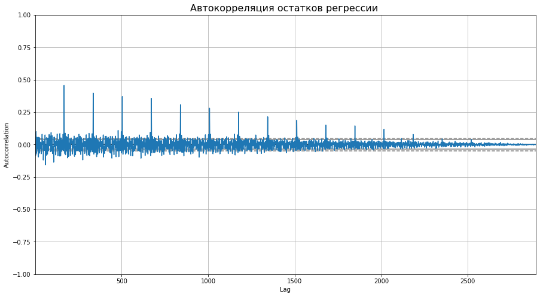

```python
series = best_model.resid[8766:]

autocorrelation_plot(series)
#plt.axis([0,30,-0.4,0.4])
plt.title('Автокорреляция остатков регрессии ', fontsize=16)
pyplot.show()
```

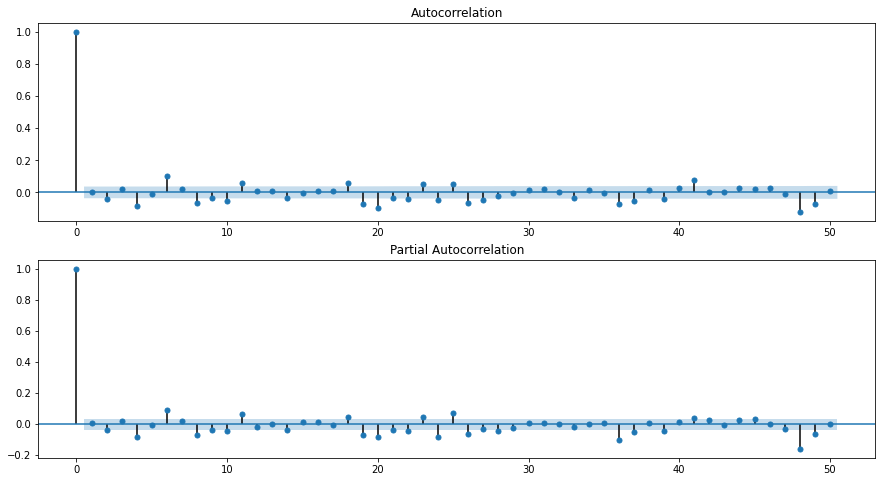

```python
res = best_model.resid[8766:]
fig, ax = plt.subplots(2,1)
fig = sm.graphics.tsa.plot_acf(res, lags=50, ax=ax[0])
fig = sm.graphics.tsa.plot_pacf(res, lags=50, ax=ax[1])
plt.show()
```

```python
print("Критерий Стьюдента: p=%f" % stats.ttest_1samp(best_model.resid[8766:], 0)[1])
print("Критерий Дики-Фуллера: p=%f" % sm.tsa.stattools.adfuller(best_model.resid[8766:])[1])
```

```
Критерий Стьюдента: p=0.886615
Критерий Дики-Фуллера: p=0.000000
```

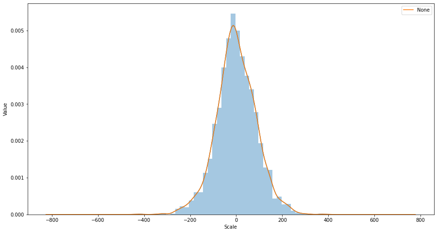

```python
sns.distplot(best_model.resid[8766:].values, bins = 40)
best_model.resid[8766:].plot(kind='kde')

plt.xlabel('Scale', )
plt.ylabel('Value')
plt.legend()
```

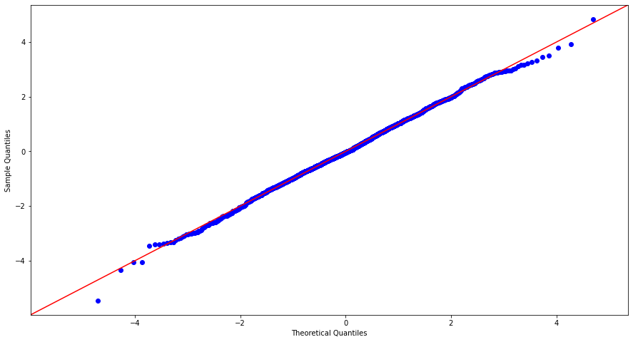

```python
from statsmodels.graphics.gofplots import qqplot
import scipy.stats as stats
fig = sm.qqplot(best_model.resid[8766:], stats.t, fit=True, line='45')
plt.show()
```

The risiduals looks like normal, in the main

## Plotting SARIMA forecasting model

```python
train['model'] = best_model.fittedvalues
plt.figure(figsize(15,7))
train.loc['2015-02-01':]['Count'].plot(label = u'Реальное количество поездок')
train.loc['2015-02-01':].model.plot(color='r', label = u'Предсказаное количество поездок SARIMAX')
plt.legend()
plt.ylabel(u'Количество поездок')
pylab.show()
```

[output not shown]

## Evaluation of the SARIMA forecasting model

```python
from sklearn.metrics import r2_score
r2 = r2_score(train['2015-02-01':]['Count'], train['2015-02-01':]['model'])
print( 'R^2: %1.2f' % r2)
```

```
R^2: 0.94
```

## Comparison with the accuracy of the regression model

```python
train_regress=train_regected

X=np.array(train_regress.iloc[:,1:])
Y=np.array(train_regress.iloc[:,:1:]).reshape(-1)

model = XGBRegressor()
# fit the model
model.fit(X, Y)
preds = model.predict(X)
model.fit(X, Y).score(X, Y)
```

```
0.9218984408076611
```

Looks like SARIMA model made better predictions on the training data set.

# Trips forecast per hour in May

## Accuracy of the regression model in May

```python
## задаю обучение регрессии на той же выборке где обучалась SARIMAX
train_regress=train_regected

X=np.array(train_regress.iloc[:,1:])
Y=np.array(train_regress.iloc[:,:1:]).reshape(-1)

## задаю выборку предсказания на май месяц
x_test=np.array(grouped.loc['2016-05-01':'2016-05-30'][sorted(column_list)].iloc[:,1:])
y_test=np.array(grouped.loc['2016-05-01':'2016-05-30'][sorted(column_list)].iloc[:,:1:]).reshape(-1)

## обучаю модель на выборке, где обучалась SARIMAX
model = XGBRegressor()
# fit the model
model.fit(X, Y)

## Делаю предсказание модели на май месяц
preds = model.predict(x_test)
```

Accuracy metrics

```python
from statsmodels.tsa.stattools import acf
from sklearn.metrics import r2_score

# Accuracy metrics
def forecast_accuracy(forecast, actual):
    mape = np.mean(np.abs(forecast - actual)/np.abs(actual))  # MAPE
    me = np.mean(forecast - actual)             # ME
    mae = np.mean(np.abs(forecast - actual))    # MAE
    mpe = np.mean((forecast - actual)/actual)   # MPE
    rmse = np.mean((forecast - actual)**2)**.5  # RMSE
    corr = np.corrcoef(forecast, actual)[0,1]   # corr
    mins = np.amin(np.hstack([forecast[:,None],
                              actual[:,None]]), axis=1)
    maxs = np.amax(np.hstack([forecast[:,None],
                              actual[:,None]]), axis=1)
    minmax = 1 - np.mean(mins/maxs)             # minmax
    acf1 = acf(forecast-actual)[1] # ACF1
    r2 = r2_score(actual, forecast)
    return({'mape':mape, 'me':me, 'mae': mae,
            'mpe': mpe, 'rmse':rmse, 'acf1':acf1,
            'corr':corr, 'minmax':minmax, 'R^2':r2})



#> {'mape': 0.02250131357314834,
#>  'me': 3.230783108990054,
#>  'mae': 4.548322194530069,
#>  'mpe': 0.016421001932706705,
#>  'rmse': 6.373238534601827,
#>  'acf1': 0.5105506325288692,
#>  'corr': 0.9674576513924394,
#>  'minmax': 0.02163154777672227}
```

```python
## Делаю оценку регрессии на тестовой майской выборке
fс_regress=preds
test_regr=y_test
forecast_accuracy(fс_regress, test_regr)
```

```
{'mape': 0.19490231772473146,
 'me': 77.13621349069807,
 'mae': 103.09994485908085,
 'mpe': 0.14478240255512026,
 'rmse': 141.64187296043397,
 'acf1': 0.6802244972088923,
 'corr': 0.9407479250137163,
 'minmax': 0.14595541447805416,
 'R^2': 0.8028928539570386}
```

## Accuracy of the SARIMA model in May

```python
train_result_2=train[8766:][['Count']]
date_list = [datetime.strptime("2016-04-30 23", "%Y-%m-%d %H") + relativedelta(hours=x) for x in range(0,720)]
future = pd.DataFrame(index=date_list, columns= train_result_2.columns)
future_regression=future
future_regression['preds_regression']=fс_regress
train_result_2 = pd.concat([train_result_2, future])
```

```python
train_result_2.shape
```

```
(12378, 2)
```

```python
train_data.shape
```

```
(11658,)
```

```python
train_result_2['forecast'] = best_model.predict(start=11658, end=12377, exog=test_gr[sorted(column_list)].iloc[:,1:] )
train_result_2['real_count']=test_gr.Count
```

## Plotting SARIMA forecasting model in May

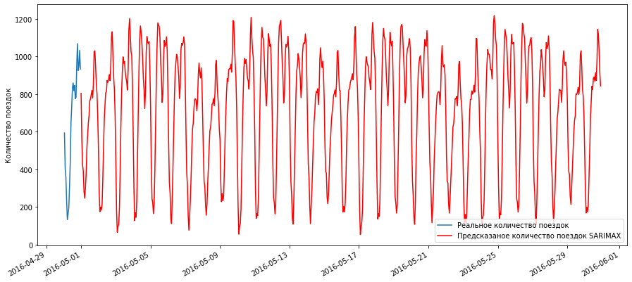

```python
plt.figure(figsize(15,7))
train_result_2.loc['2016-04-30 01:00:00':'2016-05-30'].Count.plot(label = u'Реальное количество поездок')
train_result_2.loc['2016-04-30 01:00:00':'2016-05-30'].forecast.plot(color='r', label = u'Предсказаное количество поездок SARIMAX')
plt.legend()
#future_regression.preds_regression.plot(color='g')
plt.ylabel('Количество поездок')
#plt.axis(['2016-04-30','2016-05-30',-250,1250])
pylab.show()
```

## Evaluation of the SARIMA forecasting model in May

```python
fc=train_result_2['2016-05-01':].forecast
test=train_result_2['2016-05-01':].real_count
forecast_accuracy(fc, test)
```

```
{'mape': 0.2609788766988138,
 'me': 60.772203723976446,
 'mae': 110.1939521545495,
 'mpe': 0.18511000708001743,
 'rmse': 140.71169976517476,
 'acf1': 0.7182462139493254,
 'corr': 0.9202352805165842,
 'minmax': 0.1769742602200315,
 'R^2': 0.8055060234656009}
```

# Enlarged plotting

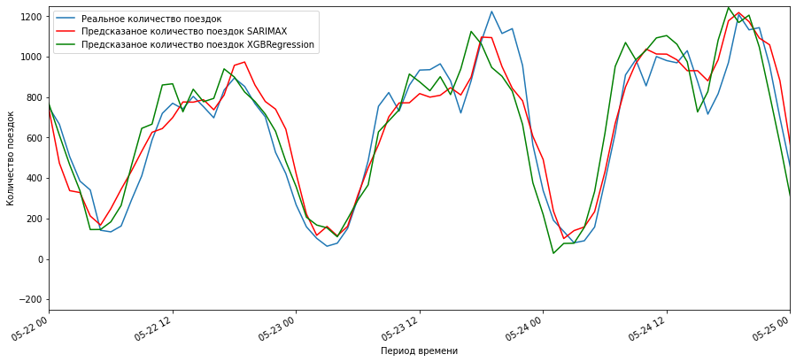

```python
plt.figure(figsize(15,7))
train_result_2.real_count.plot(label = u'Реальное количество поездок')
plt.legend()
train_result_2.forecast.plot(color='r', label = u'Предсказаное количество поездок SARIMAX')
plt.axis(['2016-05-22','2016-05-25',-250,1250])
plt.legend()
future_regression.preds_regression.plot(color='g', label = u'Предсказаное количество поездок XGBRegression')
plt.legend()
plt.ylabel(u'Количество поездок')
plt.xlabel(u'Период времени')
pylab.show()
```

```python
from sklearn.metrics import r2_score
r2 = r2_score(train_result_2.real_count.loc['2016-05-22':'2016-05-25'], train_result_2.forecast.loc['2016-05-22':'2016-05-25'])
print( 'R^2: %1.2f' % r2)
```

```
R^2: 0.89
```

# Comparison of May Prediction Models

Comparison of models trained on different parametrs, different length of the train sample, different number of features (20, 40, 43), with included or not holidays

```python
metric_result=pd.read_csv('forecast_metrics.csv', sep=';')
metric_result.sort_values('mape', ascending=True)
```

|  | forecast_type | num_future | holydays | train_data_time_period | mape | me | mae | mpe | rmse | acf1 | corr | minmax | R^2 |
| --- | --- | --- | --- | --- | --- | --- | --- | --- | --- | --- | --- | --- | --- |
| 7 | XGBRegressor | 43 | on | 2 year 4 month | 0.194900 | 77.136213 | 103.099940 | 0.144782 | 141.641873 | 0.680224 | 0.940748 | 0.145955 | 0.802893 |
| 8 | 40 | 20 | NaN | 4 month | 0.245580 | 59.924380 | 115.777320 | 0.126070 | 150.873590 | 0.753290 | 0.914820 | 0.182980 | 0.776400 |
| 4 | 1040 | 40 | NaN | 4 month | 0.257780 | 72.232680 | 118.443530 | 0.166560 | 153.621530 | 0.743970 | 0.916380 | 0.183260 | 0.768180 |
| 5 | 1030 | 40 | NaN | 4 month | 0.257880 | 68.519860 | 116.961210 | 0.169150 | 151.413700 | 0.726450 | 0.914930 | 0.181470 | 0.774800 |
| 9 | 3040 | 43 | on | 1 year 4 month | 0.259290 | 62.521640 | 111.883850 | 0.179170 | 142.962410 | 0.723610 | 0.919620 | 0.178270 | 0.799230 |
| 0 | 2040 | 43 | on | 1 year 4 month | 0.260980 | 60.772200 | 110.193950 | 0.185110 | 140.711700 | 0.718250 | 0.920240 | 0.176970 | 0.805510 |
| 1 | 2040 | 40 | no | 1 year 4 month | 0.269830 | 69.139340 | 112.473080 | 0.203200 | 143.211430 | 0.713450 | 0.921960 | 0.179810 | 0.798530 |
| 11 | 4030 | 43 | on | 2 year 4 month | 0.273841 | 65.634590 | 113.563919 | 0.199668 | 144.221915 | 0.705605 | 0.918654 | 0.182572 | 0.795681 |
| 10 | 4040 | 43 | on | 1 year 4 month | 0.276482 | 72.426828 | 115.746347 | 0.204288 | 146.721745 | 0.720139 | 0.921110 | 0.184633 | 0.788537 |
| 2 | 1040 | 20 | NaN | 4 month | 0.278640 | 36.540360 | 123.861810 | 0.128990 | 158.461440 | 0.564730 | 0.881260 | 0.196880 | 0.753340 |
| 3 | 1040 | 40 | NaN | 1 year 4 month | 0.279210 | 72.043910 | 113.690030 | 0.218010 | 144.438450 | 0.710330 | 0.921640 | 0.182250 | 0.795070 |
| 6 | 1030 | 20 | NaN | 4 month | 0.284160 | 25.500600 | 128.504610 | 0.073360 | 162.612840 | 0.620260 | 0.877440 | 0.216520 | 0.740250 |

```python
metric_result.sort_values('minmax', ascending=True).head(3)
```

|  | forecast_type | num_future | holydays | train_data_time_period | mape | me | mae | mpe | rmse | acf1 | corr | minmax | R^2 |
| --- | --- | --- | --- | --- | --- | --- | --- | --- | --- | --- | --- | --- | --- |
| 7 | XGBRegressor | 43 | on | 2 year 4 month | 0.19490 | 77.136213 | 103.09994 | 0.144782 | 141.641873 | 0.680224 | 0.940748 | 0.145955 | 0.802893 |
| 0 | 2040 | 43 | on | 1 year 4 month | 0.26098 | 60.772200 | 110.19395 | 0.185110 | 140.711700 | 0.718250 | 0.920240 | 0.176970 | 0.805510 |
| 9 | 3040 | 43 | on | 1 year 4 month | 0.25929 | 62.521640 | 111.88385 | 0.179170 | 142.962410 | 0.723610 | 0.919620 | 0.178270 | 0.799230 |

```python
metric_result.sort_values('corr', ascending=False).head(3)
```

|  | forecast_type | num_future | holydays | train_data_time_period | mape | me | mae | mpe | rmse | acf1 | corr | minmax | R^2 |
| --- | --- | --- | --- | --- | --- | --- | --- | --- | --- | --- | --- | --- | --- |
| 7 | XGBRegressor | 43 | on | 2 year 4 month | 0.19490 | 77.136213 | 103.09994 | 0.144782 | 141.641873 | 0.680224 | 0.940748 | 0.145955 | 0.802893 |
| 1 | 2040 | 40 | no | 1 year 4 month | 0.26983 | 69.139340 | 112.47308 | 0.203200 | 143.211430 | 0.713450 | 0.921960 | 0.179810 | 0.798530 |
| 3 | 1040 | 40 | NaN | 1 year 4 month | 0.27921 | 72.043910 | 113.69003 | 0.218010 | 144.438450 | 0.710330 | 0.921640 | 0.182250 | 0.795070 |

```python
metric_result.sort_values('R^2', ascending=False).head(3)
```

|  | forecast_type | num_future | holydays | train_data_time_period | mape | me | mae | mpe | rmse | acf1 | corr | minmax | R^2 |
| --- | --- | --- | --- | --- | --- | --- | --- | --- | --- | --- | --- | --- | --- |
| 0 | 2040 | 43 | on | 1 year 4 month | 0.26098 | 60.772200 | 110.19395 | 0.185110 | 140.711700 | 0.718250 | 0.920240 | 0.176970 | 0.805510 |
| 7 | XGBRegressor | 43 | on | 2 year 4 month | 0.19490 | 77.136213 | 103.09994 | 0.144782 | 141.641873 | 0.680224 | 0.940748 | 0.145955 | 0.802893 |
| 9 | 3040 | 43 | on | 1 year 4 month | 0.25929 | 62.521640 | 111.88385 | 0.179170 | 142.962410 | 0.723610 | 0.919620 | 0.178270 | 0.799230 |

The best model among the others can only be estimated in four ways: mape, minmax, corr and r2, as they are in percentage